# CSE2215 - Computer Graphics 2021-2022 - Final Project

## 2. Basic description

In this project, you will build upon the shading and intersection tests that you implemented in the assignments. By the end of a successful project you will have created a fully functional ray-tracer.

The user interface enables you to choose from a selection of test scenes to work with, including a custom scene. It initially loads a scene custom.obj in the data folder. If you like to load your own scene, you can simply overwrite the corresponding `custom.obj` with your own scene (please note that you should not rename your obj material file (MTL), as the original filename is mentioned within the obj file itself).

The provided framework is similar to the code you worked with in the Ray Intersection assignment. Note that the sphere, triangle and mesh intersection methods now have an additional (output) argument `hitInfo`. `HitInfo` that can be used to store information about an intersection point that can then be used for shading, such as the surface normal, texture coordinates, barycentric coordinates and the material.

Please see the Appendix for a more detailed description about Materials. You can store this information after a successful intersection test.

```cpp
// Defined in common.h;
struct HitInfo {
    glm::vec3 normal;
    glm::vec2 texCoord;
    glm::vec3 barycentricCoord;
    Material material;
};

// Intersection methods are called from bounding_volume_hierarchy.cpp
bool BoundingVolumeHierarchy::intersect(Ray& ray, HitInfo& hitInfo, const Features& features) const
```

### Compilation

We provided a prebuilt library for the required Windows environment with the reference solutions for the intersection functions, hence the `intersect.h` and `intersect.cpp` files are not used by default. If, instead, you wish to use your own function from the previous assignment, you can use these files and pass the following argument to CMAKE: “-DUSE_PREBUILT_INTERSECT=OFF”. In this case the prebuilt library will be ignored. We have also included libs for Mac and Linux but we cannot guarantee they will work with your compiler and OS version (you might need to use the solution without the prebuilt lib in this case).

For a start, you can compile the code and test the application. Note that you can compile the code in two different modes “Debug” or “Release”. When compiled in “Debug” mode, there are a lot of additional tests that are done behind the scenes, e.g., if you are accessing a std::vector, it always checks that you stay within its bounds. It is very useful to compile in “Debug” mode when developing code to ensure that all these tests are performed. Nevertheless, once the code is working, you should switch to “Release”. If you now compile the code, it will be highly optimized and result in a tremendous speedup. Especially, when working with complicated scenes, it is a good idea to rely on “Release” mode. In the same spirit, when in “Debug” mode, you should rather work with simpler scenes to avoid long wait times.

Whatever the mode, once compiled, you can launch the application.

When testing your implementation, we will use Visual Studio on Windows to compile your work, as for the assignments. Please note that you **should not** (and do not have to) use any external libraries (except for the included `intersect.lib`). If you do, please make sure that your project can be compiled without any extra efforts or it might affect the grading.

### Rasterization mode

From the menu, you can choose a “Rasterization” and a “Raytracing” view mode. The OpenGL Rasterization mode will be used for debugging and interaction. The “Ray traced” view mode will launch actual rays per pixel. You can also click the “Render to file” button to save the ray-tracing result to a file.

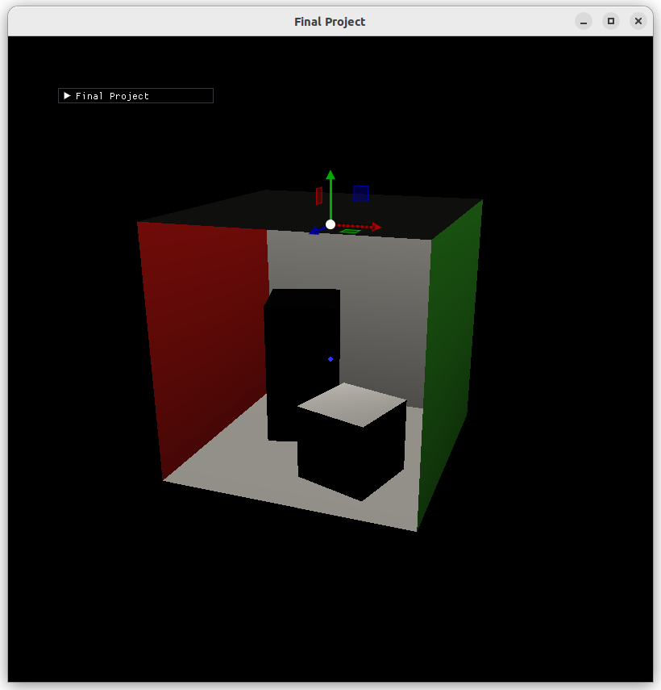

Screenshot of the raster view.

You can also insert, remove and modify light sources using the GUI in Rasterization mode. The light sources will be used for ray-tracing. But please note that the illumination in Raterization mode will not necessarily correspond to the illumination in Ray-Trace mode. Here, we just placed a single light source for the scene to have some illumination.

### Ray-Trace Mode

To produce an actual ray-traced image, you switch to the “Ray Traced” view mode. Here, the program will generate one ray for each pixel on the screen. Ultimately, for each such pixel, you will compute a RGB colour value by determining the light that is reflected towards the camera pixel, taking reflections, shadows and other effects into account. The entry point for your implementation is the `getFinalColor(...)` function in `render.cpp`.

If you press “Render to file” the image is ray traced and written to a file. This functionality is also available in the rasterization mode, so you can render to file without switching to the actual Ray-Trace Mode. **Make sure the path to this folder does not contain any special characters (only ascii characters)**.

For a simple scene, the Ray-trace mode might be interactive but as soon as the amount of geometry increases and the effects become more complex, the process will be costly. In consequence, you will also be asked to create a data-structure to accelerate your ray-tracer, as we will outline in detail below.

Rendering the Cornell Box without any features enabled should result in the following image. If you are using the provided intersect prebuilt library, you should be able to reproduce this result just by running the program before altering any code.

[figure not shown]

Screenshot of the raster view.

When a scene is loaded, it is centered and scaled to a `[-1,1]x[-1,1]x[-1,1]` volume. Hereby, the placing of the light sources in the scene via the interface is facilitated. Via the interface, you can add light sources, change their type/color or move them around.

Additional advice regarding the code and use of specific classes can be found in the appendix of this document.

### Visual Debug

You are asked to implement one Visual Debug for each ray-tracing feature. The Visual Debug is always the element to start with, and it should aid in verying the correctness of your implementation. By having visual feedback of your calculations, you are able to catch bugs early on in the development. **The Visual Debug is always worth at least 50% of a feature’s points**.

The visual debugger can be implemented in the same functions as the rest of your ray tracer, but it should be easily findable.

To get you started with the visual debug, by pressing `r` when in “Rasterization” mode you can launch a single debug ray through the mouse cursor. You will expand this debugging feature throughout the project, as it is a useful way to illustrate how the ray progresses through the scene; you can visually inspect if reflections are going in the right direction and the correct material properties are recovered.

Experiment with the debugging outputs. For example, you can color the ray to illustrate the current depth with respect to the number of reflections, or you can draw a line to show each normal of the surfaces that are encountered by the ray. For other features you will need other forms of visual debug that are not based on drawing lines. You might notice quickly that these types of outputs are very useful when debugging your work.

## Feature Flags

Each basic and extra feature has a corresponding flag to enable/disable it. The flags are in the `common.h` file and can be also toggled via the interface. Every feature you implement needs to be enabled/disabled via these flags. **These flags will be used during grading to isolate the features, so make sure they are working properly.** For example, when grading shadows we will sometimes disable BVH, textures and other non-related features.

The flags are also very useful to isolate the feature you are currently implementing. You can also use them to enable/disable corresponding visual debugs in the code.

## 3. Standard features

Below, you will find a list of features with an indication of how many points they represent.

You are free to work on extra features but you **have to first finish the standard features** attributed to you.

Below, we list the *standard features*

- [0.5] shading using Phong Illumination Model
- [2.0] recursive ray-tracer
- [1.0] hard shadows
- [4.0] area lights
- [5.0] acceleration data-structure generation
- [3.0] acceleration data-structure traversal
- [1.0] normal interpolation with barycentric coordinates
- [1.5] texture mapping

Note that each of these standard features consists of the actual feature to be implemented, as well as a visual debugger, whose importance was outlined above. The indicated points are the maximum, assuming that the implementation is entirely correct and the visual debugger attends the requirement of showing the correctness of the implementation.

Some features also depend on others. We have noted the dependencies in the feature descriptions below to allow for the group to better plan the work distribution. We recommend that features that depend on others be handled by the same members.

**Important:** All standard features should be implemented using the methods and flags available. Make sure you do not change method names and work with the given framework and files. You can create additional methods, but when grading we will always start by calling the ones that are already given. The corresponding flags, methods and files are indicated below for each feature.

### 3.1 Shading

This feature is basically what you have already done in Assignment 3. It will add the Phong Illumination Model to your ray tracer.

#### Corresponding Methods:

- `computeShading(...)` in file `shading.cpp`: for a given light source or sample compute the direct illumination using the Phong Model at an intersection point.
- `computeLightContribution(...)` in file `light.cpp`: this method is called from `getFinalColor(...)` in `render.cpp`. Cycle through all the light sources and respective samples (if area or segment light) and compute the contributions using the function above (‘computeShading’) for each one. You can access the light sources via `scene.lights` and the material parameters can be passed along by the intersection function using the `HitInfo` struct as described above.

#### Corresponding Flag:

- `enableShading`: when disabled the material diffuse color (kd) will be used during rendering. Note that no illumination is taken into account when disabled.

#### Example Output:

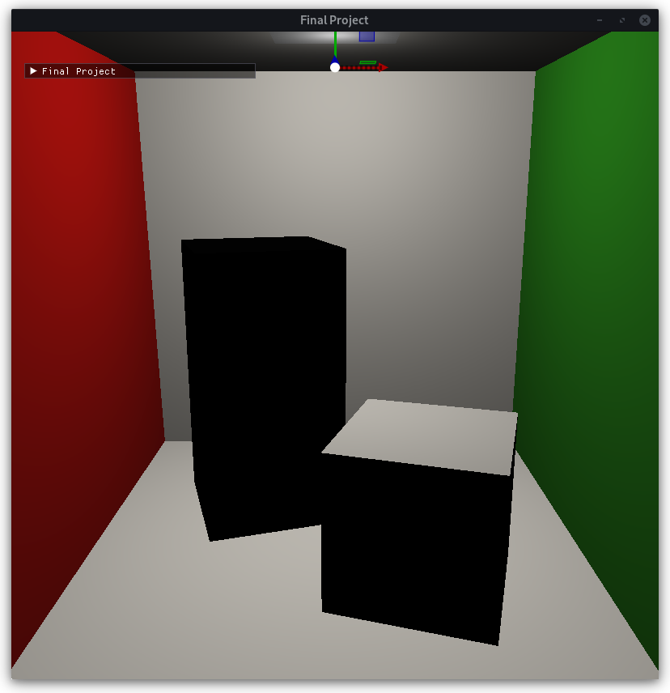

Example of shading feature. Note that mirror surfaces (no diffuse component) are rendered as black since there is no recursion yet.

#### Visual debug:

- draw the camera ray using the `drawRay(ray, color)` function that is defined in `draw.h`. Use the color from the shading function to color your ray. This function can be called from within `getFinalColor(...)`. Tip: call `drawRay(...)` after you intersect the ray so the ray has a length (`ray.t`).

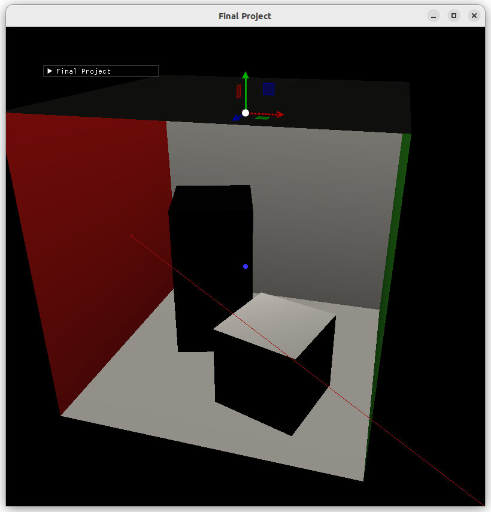

Example of what the visual debug might look like.

### 3.2 Recursive ray-tracer

##### depends on: Shading

Now you need to recursively trace rays that intersect specular surfaces. Every time the ray intersects a specular surface (`material.ks` is not black), you should trace another ray in the mirror-reflection direction. The reflected ray will contribute additional light to the specular component of the illumination model.

#### Corresponding Methods:

- `computeReflectionRay(...)` in file `shading.cpp`: given the Ray and an intersection point, compute the specular reflected ray
- `getFinalColor(...)` in file `render.cpp`: recursively trace the rays

#### Corresponding Flag:

- `enableRecursive`

#### Example Output:

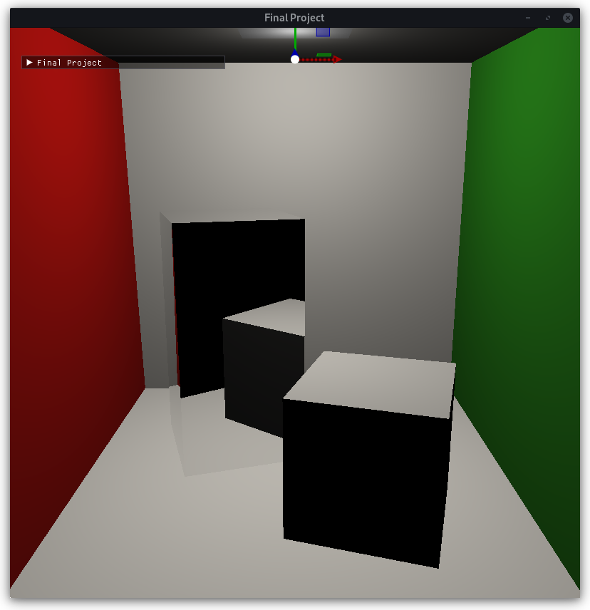

Example of recursive ray-tracer with shading

#### Visual debug:

- extend upon the visual debug from the Ray Intersection assignment by also drawing the reflected rays. This should be combined with the visual debug from shading (above).

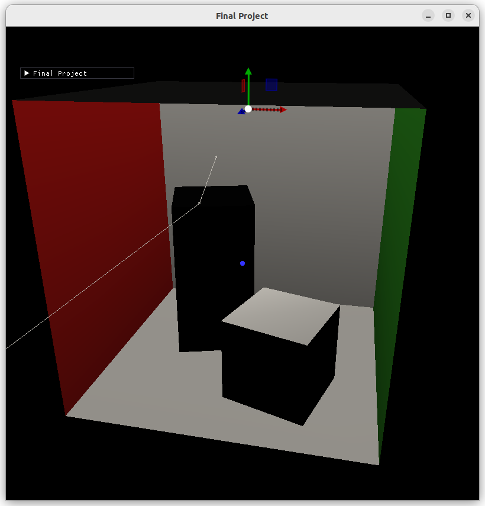

Example of what the visual debug might look like.

### 3.3 Hard shadows

For point light sources you should compute hard shadows. At each intersection point cast a shadow ray towards each light source to determine if the point is in shadow or not. If the point is in shadow for a light source, then that light source should not contribute to the shading computation.

#### Corresponding Method:

- `testVisibilityLightSample(...)` in file `light.cpp`: check if a given light sample is visible from an intersection point

#### Corresponding Flag:

- `enableHardShadow`

#### Example Output:

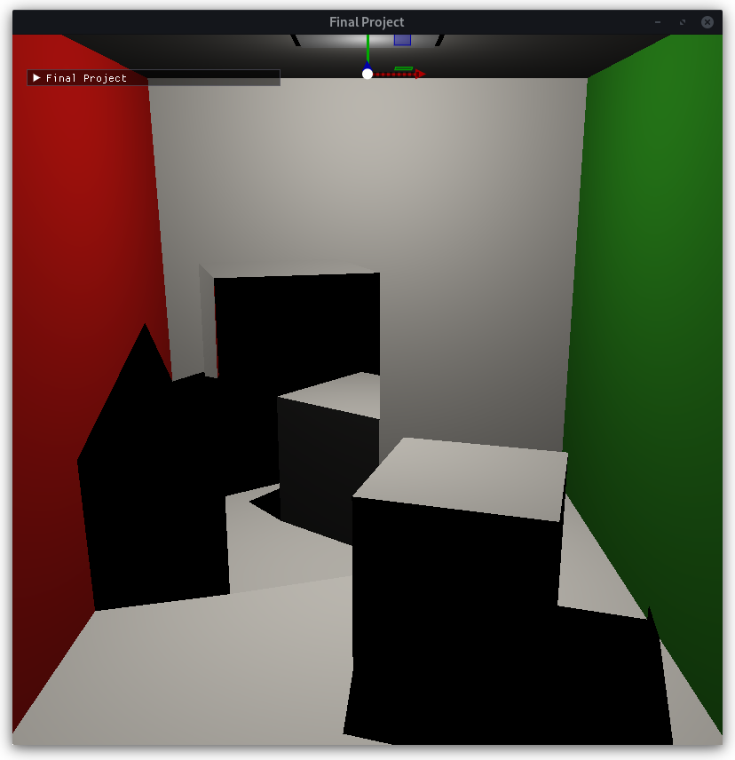

Example of hard shadows

#### Visual debug:

- draw the shadow ray. If the shadow ray is occluded (it hits something other than the light) then draw it in a different colour such as red. This debug display should be combined with the visual debug for shading and the recursive ray-tracer.

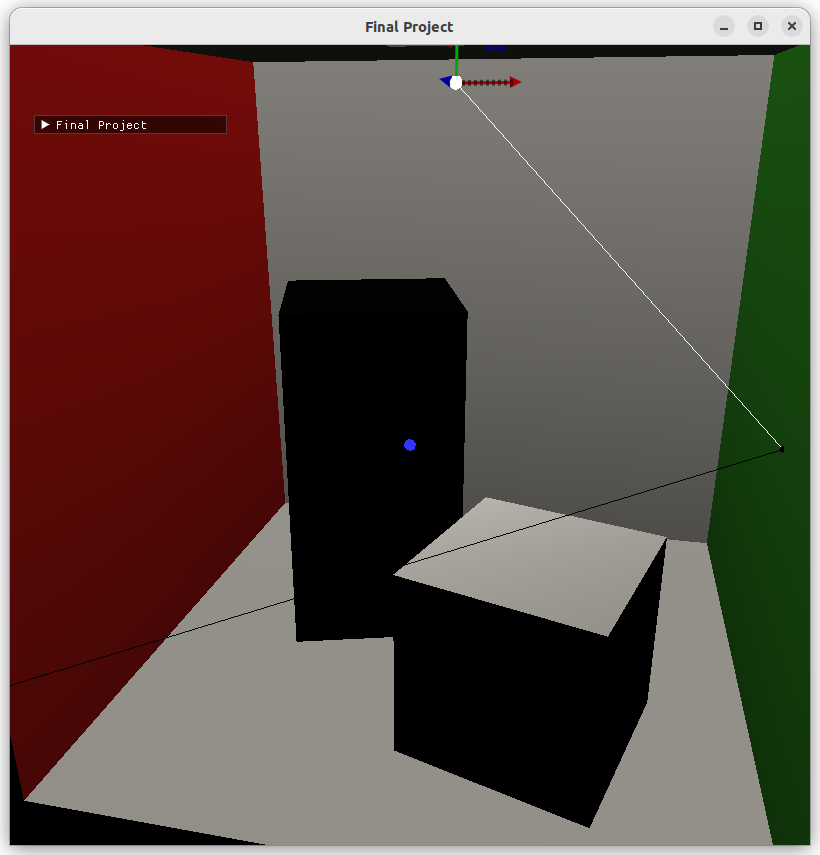

Example of what the visual debug might look like.

### 3.4 Area lights

##### depends on: Hard Shadows and Shading

Instead of a point light source, now you should create light sources that extend in one or more dimensions. These light sources need to be sampled with multiple rays to determine the percentage of coverage and the final color. The implemented sampling method should be described and justified in the report.

For shading with colored lights, you should average the shading result from all rays that hit the light source.

You should implement the two types of light sources below:

**Segment light Source**: Defined by two endpoints and their colors. To compute the color at a given point on the segment use linear interpolation. Make sure you test (and include in your report) the results of a segment light source with different colors for each endpoint (e.g., red and blue).

**Parallelogram light source**: Defined by one corner point (position) and two edge vectors (see book page 332 for an illustration). Again the colors are defined at each corner point. To compute the color inside the parallelogram use bilinear interpolation. Note that the bilinear interpolation should be computed in 2D. Illustrate the case with different colors per corner in your report.

#### Corresponding Methods:

- `sampleSegmentLight(...)` in file `light.cpp`: sample a position in a segment light source and compute the corresponding color using linear interpolation
- `sampleParallelogramLight(...)` in file `light.cpp`: sample a position in a parallelogram light source and compute the corresponding color using bilinear interpolation

#### Corresponding Flag:

- `enableSoftShadow`

#### Example Output:

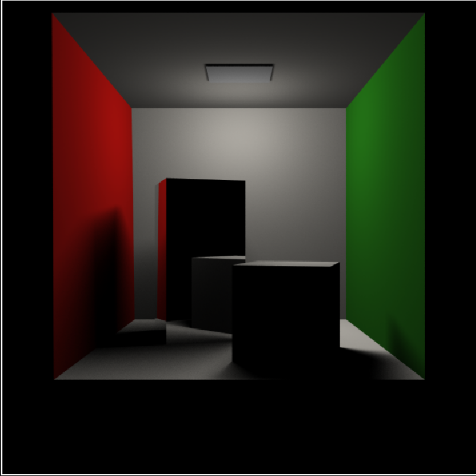

Example of what the soft shadow might look like.

#### Visual debug:

- as with the hard shadows, draw all the rays that you sample and color them according to whether they hit the light or not. If the ray hits the light source it should be colored using the light source interpolated color at that position.

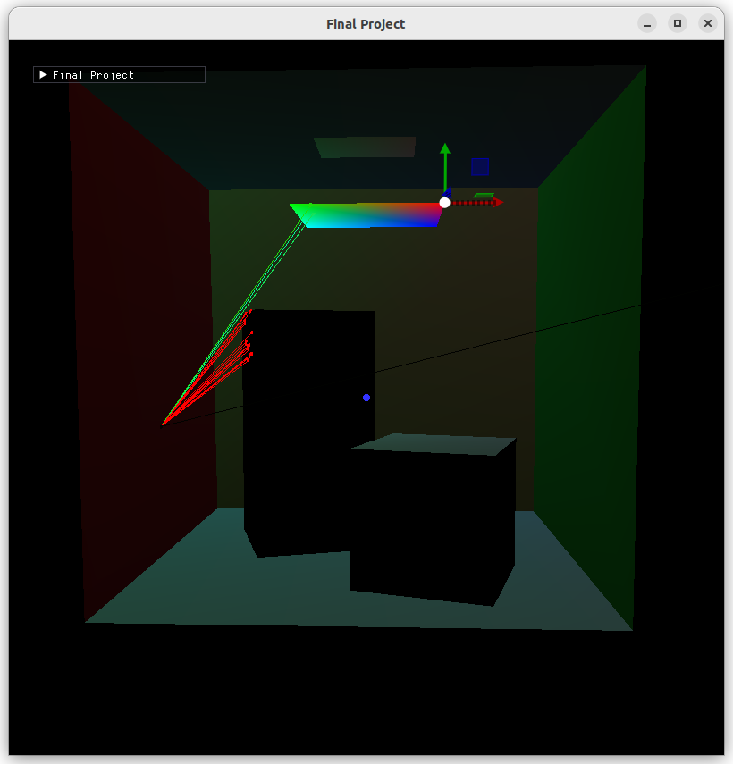

Example of what the visual debug might look like.

### 3.5 Acceleration data-structure without pointers

This is the most laborious part of the final project and the requirement that will allow you to render large scenes in a reasonable amount of time. You should implement a **Bounding Volume Hierarchy**, or BVH for short. Use **Axis-Aligned Bounding Boxes** as bounding volumes (as seen in the lecture) and a binary tree (every parent node has two child nodes). The `AxisAlignedBox` structure is defined in the `common.h` file.

Note that the instructions below are requirements, not suggestions. Not following the requirements may lead to point subtraction.

### 3.5.1 Acceleration data-structure: Creation

Initially, create an AABB that contains the entire scene. Then subdivide it creating two new child AABBs, and distribute the content among the children. You should then proceed to subdivide the child nodes recursively, constructing the hierarchy. Don’t forget to limit the maximum number of levels of your hierarchy.

You should implement the following subdivision criterion:

**median with alternating axis**: split at the median centroid of all triangles in the node. Alternate the splitting axis with each new subdivision level. Use the following order: *x-y-z* for alternating the splitting axis. In which child node the splitting triangle (median) is placed is up to you, but be consistent.

The bounding volume hierarchy only has to work for meshes, support for spheres is optional. Organize your BVH such that you do **not use pointers** and instead rely on the standard std::vector class.

We have already set up the basic methods inside the `bounding_volume_hierarchy` files. Use these files to implement your BVH (do not modify the `bvh_interface` files). Initially, there is no BVH, so the intersection method loops over all meshes to test for intersection against all primitives. You will implement several methods in the BoundingVolumeHierarchy class to create this data structure.

#### Corresponding Methods:

(all in files `bounding_volume_hierarachy.*`)

- `Constructor`: To construct the BVH you need to create a `Node` struct in the `bounding_volume_hierarchy.h` file (you can look at the `common.h` file for some struct examples). All the nodes are stored in a *node vector* of type `std::vector<Node>`. A node can be of two types: *interior* or *leaf* node. Use a *boolean* to identify the Node type. Every node contains its bounds and its own `std::vector` that is used to store the indices of the two child nodes in the *node vector* (in case of a parent node) or store the indices of the contained triangles (in case of a leaf node). Note that you also need to store the index of the corresponding mesh for each triangle but you can only use one vector to store everything, hence you need to come up with an efficient way to store and access the data.
- `numLevels`: returns the number of levels in your hierarchy (important to set the corresponding VisualDebug slider)
- `numLeaves`: returns the number of leaf nodes in your hierarchy (important to set the corresponding VisualDebug slider)
- `debugDrawLevel`: see VisualDebug1 below
- `debugDrawLeaf`: see VisualDebug2 below

#### Corresponding Flag:

- `enableAccelStructure`

#### Visual debugs:

- visualize one level of the hierarchy at a time by drawing the respective AABBs. The GUI contains a button to enable/disable the BVH visualization for debugging. If enabled, an additional slider will become available to choose the level in the hierarchy. This value is passed as input to the `debugDrawLevel` function.
- draw only one *leaf* node and its contained triangles. When this debug mode is enabled the mesh will be drawn with a slight offset to avoid overlapping with the leaf’s triangles that you draw. A slider becomes available to choose the leaf node and the value is passed as input to the `debugDrawLeaf` function.

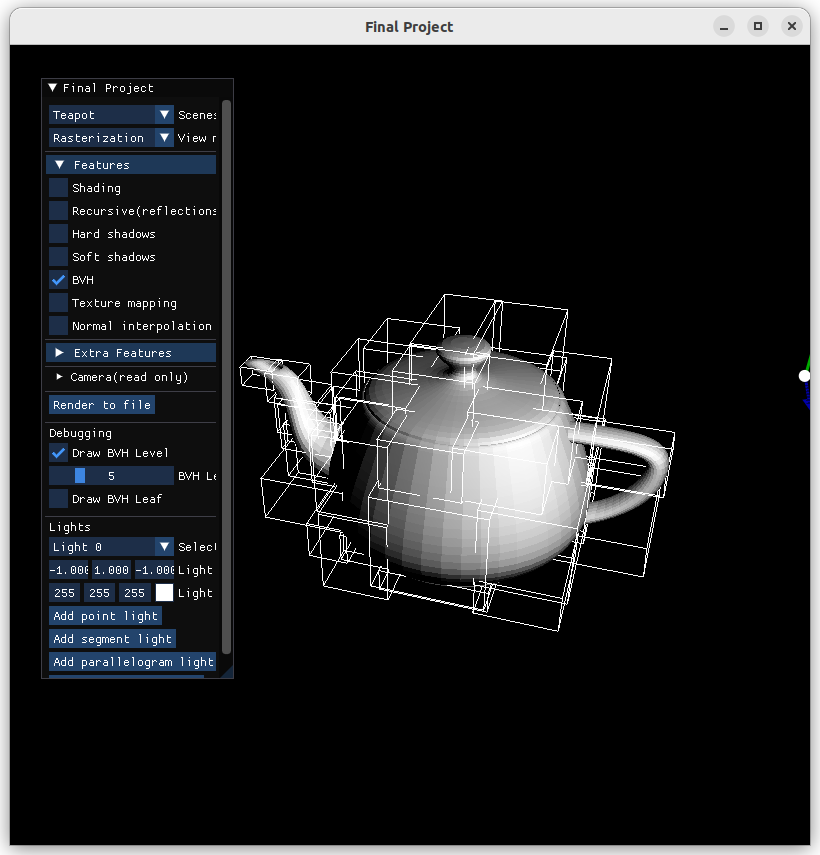

Example of what the first visual debug for bvh creation might look like.

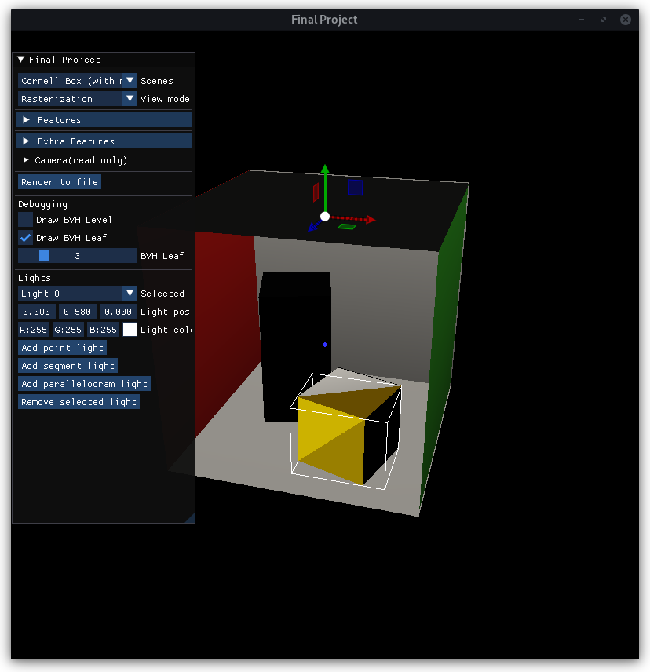

Example of what the second visual debug for bvh creation might look like.

### 3.5.2 Acceleration data-structure: Traversal

##### depends on: Data-structure Creation and on Recursive Ray Tracing

Once your hierarchy is constructed and you are able to visually debug it, you can finally implement the ray against BVH intersection test.

Start with a basic, but less efficient, traversal. For each interior node that the ray intersects, test the ray intersection against the two child nodes recursively. Once you reach a leaf node, test the intersection of the ray with all triangles stored at the node.

Once this is working, you should optimize your traversal. Keep the list of ray-AABB intersections ordered to make sure you always continue the traversal with the closest hit so far. When the ray intersects a triangle inside a leaf node and no other node is closer to this hit point, you can stop your traversal. Remember that for the BVH the AABBs may overlap!

#### Corresponding Method:

- `intersect(...)` in `bounding_volume_hierarachy.cpp`: This method receives a ray and the `HitInfo` to be filled. Here you should traverse the hierarchy and find the closest intersection point, if any, in order to fill the HitInfo structure.

Note that for recursive ray-tracing, you might need to traverse the structure multiple times, one for each reflected ray. Make sure you account for the case when the ray origin is inside the BVH.

#### Corresponding Flag:

- `enableAccelStructure`

#### Visual debugs:

- visualize the ray-node intersections by drawing all intersected nodes and the final intersected triangle.
- create an option to draw the intersected but not visited nodes with another color. When performing recursive ray-tracing, visualize each recursion at a time.

### 3.6 Barycentric coordinates for normal interpolation

To achieve smooth shading of your models you need to interpolate the vertices normals inside the triangle intersected by a ray. Given the intersection point inside a triangle, compute its barycentric coordinates. Then use the barycentric weights to interpolate the vertices normals.

#### Corresponding Methods:

- `computeBarycentricCoord(...)` in `interpolate.cpp`: receives three vertices of a triangle and a point, computes the barycentric coordinates at the given point
- `interpolateNormal(...)` in `interpolate.cpp`: given three normals and barycentric coordinates, compute the interpolated normal

#### Corresponding Flag:

- `enableNormalInterp`

#### Visual debug:

- visualize the normals at the vertices and the interpolated normal. The more curved the surface is (the more the vertices normals deviate), the easier to see the effect. Intersect the same triangle at different positions to see how the interpolated normal behaves.

### 3.7 Textures

##### depends on: Barycentric Coordinates

To give the looks of your rendered images an extra boost you should add textures to the ray-tracer. For a point inside a triangle you can compute the corresponding texture coordinates using the barycentric weights computed in the feature above.

#### Corresponding Methods:

- `interpolateTexCoords(...)` in `interpolate.cpp`: given three texture coordinates and barycentric coordinates, compute the interpolated texture coordinates
- `acquireTexel(...)` in `texture.cpp`: given texture coordinates, retrieve the corresponding pixel in an image

#### Corresponding Flag:

- `enableTextureMapping`

#### Example Output:

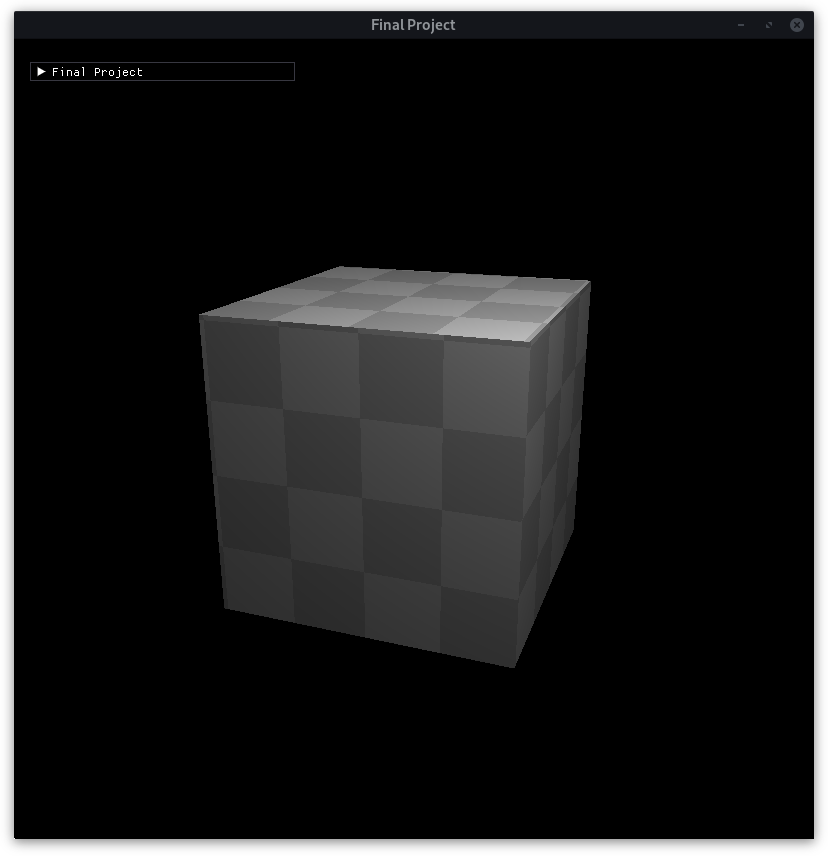

Example of what the texture mapping might look like.

#### Visual debug:

- visualize a quad (two triangles) textured with a 2x2 texture. For example, you should see the quad correctly textured without any artifacts due to the triangle borders.

## 4. Extra requirements (extra features)

Once you are done with the basic features you can implement any other feature.

For some features below, we list the corresponding points but other ideas are welcome. If you are in doubt if an idea for an extra requirement is valid or “worth it”, please send an email to cg-cs-ewi@tudelft.nl.

The suggestions can be implemented with the material from the lectures and the book (Fundamentals of Computer Graphics 4th Edition). If you deviate from these materials, justify why you made this choice (not guaranteed that you will get full points). Do not forget to cite your references!

For the extra features we expect a more detailed description in the report.

- [1.5] Environment maps. [Refer to Lecture 7 and book]
- [1.5] SAH+binning as splitting criterion for BVH (add row in performance table of report). [Refer to Lecture 9]
- [2.5] Motion blur. [Refer to Lecture 8 and book]
- [1.5] Bloom filter on the final image. [Refer to Lecture 2]
- [0.5] Texture filtering: Bilinear interpolation. [Refer to Lecture 6 and book]
- [2.0] Texture filtering: Mipmapping. [Refer to Lecture 6 and book]
- [1.5] Cast multiple rays per pixel with irregular sampling. [Refer to book]
- [2.5] Glossy reflections. Use the material shininess parameter to modulate how glossy the surface looks. [Refer to book]
- [1.5] Transparency. [Refer to Lecture 6]
- [3.0] Depth of field. [Refer to Lecture 8 and book]

**Corresponding Methods:** There are no prefixed correspoding methods. Try to isolate as best as possible the extra features. Indicate where the feature is implemented in the report.

**Corresponding Flags:** Each extra feature has an associated flag. In the same way as the basic features, it should enable/disable the extra feature. Note that if the extra feature builds upon a basic feature, the basic implementation should still work normally when the extra feature is disabled. For example, SAH+binning builds upon BVH creation and traversal, by disabling SAH and keeping BVH enable, the subdivision scheme described in the basic feature should be used.

**Visual debug:** Create a visual debugger for each extra feature and include screenshots of your debugger working. Explain how your visual debugger helps to verify the correctness of the result. You cannot just resuse a visual debug from other features, it should have something unique for the feature in question. Again, as an example, SAH+Binning should have some new visual debug other than the ones for BVH.

## 5. A note on sampling

Many features depend on sampling, such as soft shadows, multiple rays per pixel, glossy or diffuse reflections. Sampling strategies determine how you generate samples, for example multiple rays for area light. Generating regular samples (i.e., in a regular grid) usually leads to visual artifacts in the form of patterns, nevertheless, a good starting point is aiming at a uniform distribution (but not regular).

For more information on better strategies for sampling, please read the following chapters from the book Fundamentals of Computer Graphics (4th edition): -13.4 -14.4 (up to and including 14.4.2). You might also want to read Chapter 14 from the beginning as a refresher.

Note that you do not need to generate and store the samples before ray-tracing, as suggested in the book, you can also generate them during the ray-tracing execution.

If you implement other strategies than the ones found in the book, explain why you opted for something else. In any case, in the report, make sure you explain why your sampling choice is a good strategy. Don’t forget to include your references!

## 6. Report

Your report is essential for the evaluation. Read the instructions carefully and include all the required points. **We will only evaluate what you list in the report**.

Start the report with the **group number** and a **list of all members** (names and student numbers).

### 6.1 Work Distribution

With the report submit the final work distribution file. Remember that if there were changes from the planned work distribution all the group members have to agree on them.

### 6.2 Features

For **each** feature, you must include:

- **A description of the implementation**. Do not copy-paste code but describe what you did in a few sentences. For the extra features make sure to include a more detailed explanation and external resources in case you used any. The description should match what the code is performing!
- **Rendered images** (at least **two**) that properly illustrate this feature. From the images, the feature has to be clearly identifiable. For example, a render with soft-shadows does not also count for hard shadows. In the same way, you should include a couple of images for each type of light source for soft-shadows. The same reasoning holds for all other features.
- The **visual debugger** needs to be shown in at least **two** images or sequence of images (depending on the feature) to illustrate its use. This can be a screenshot from the OpenGL window. For example, for the data-structure, illustrate the different levels with multiple images and the intersected nodes of a given ray. It must be clear how the visual debugger helps to certify the correctness of the implemented method.
- For **extra features**: indication of which method(s) in which file(s) implement the feature.

**>>If you do not include these elements, you might not receive all points for a feature even if the implementation is correct<<**

All features were discussed in the lecture or in the book, or both. If you deviate from the presented methods you should explain in the report in details the solution and justify why your strategy is better. You might not get full points depending on your choice, so we suggest to stick with the methods described in the lecture or in the book.

### 6.3 Models

You can use your own or external models to produce images. Be sure to specify which model belongs to which group member. You can use models from the internet as long as there are no copyright issues. If a scene is not modelled by one of the group members, make sure to include a reference from where the scene was taken. As mentioned above, you can overwrite the file custom.obj in the data folder with your own model and it becomes directly accessible from the interface by selecting the custom scene.

### 6.4 Performance test

Provide a table with the following given scenes: Cornell Box (point light), Monkey and Dragon. You are welcome to include other scenes. It should contain the scene name, number of triangles, time required for creating and rendering with the BVH, maximum number of subdivision levels, and maximum number of triangles per leaf node. You can limit the number of maximum recursions to three. For the rendering time, try to place the camera at a position that covers well the scene.

Activate only the BVH feature, disable all other basic and extra features.

Example table (these numbers are fictional, do not use them as a reference):

|  | Cornell Box | Monkey | Dragon |
| --- | --- | --- | --- |
| Num triangles | 32 | 968 | 87K |
| Time to create | 0.02s | 0.13s | 1.3s |
| Time to render | 2.3s | 2.4s | 3.8s |
| BVH levels | 3 | 5 | 9 |
| Max tris p/ leaf node | 30 | 50 | 50 |

If you implemented the extra feature SAH, add a row to the table above to report timings for this subvision criteria. In this case, you will have two rows, one for each criterion.

You can also add more tables with performance measures, such as to illustrate the cost of a basic or extra feature, or how rendering the same model with different amounts of subdivisions for the data structure affects the render time.

For the table, there is no minimum performance required since we will run the tests in a different computer, but the time spent to ray-trace each of these scenes gives a good indicative if your code is working properly and may help you to identify possible issues with your code.

As an illustration, the tests above were executed using the reference solution and a basic laptop (Dell Latitude 7390) in Debug mode. You do not need to match these timings, but if you are off by an order of magnitude or more you can suspect that something is wrong with your BVH.

## 7. Image competition

Submit your best image to the render competition. Just include an image file in your zip folder with the name *competition-groupXX.png*.

With this competition, your group can gain up to 1.5 points for your final project grade (limited to 10). You can use any model you want but do not forget to include references. The ranking will be based on a combination of technical merit and visual quality.

## 8. Submission

Please make sure that your code compiles when you submit it. We will use Visual Studio on Windows to compile your work, as for the assignments.

- You should submit your code on Brightspace before the established final delivery deadline
- Hand in **only** source code files (not the content of the directories “debug” and “release”) in a zip folder, including your PDF report named (“report-groupXX.pdf”) and the filled `final-project-workload-final.xlsl` file.
- **Do not** submit the data folder or any models (see below for extra scenes).
- Late submissions must be submitted *as soon as possible* to the “Final Project - Late Submissions” assignment on Brightspace.
- The following penalty will be applied: $\text{adjusted grade} = \text{grade} - 1 - \lceil\frac{\text{minutes late}}{10}\rceil$

**Please upload early**, issues with uploading at the very last minute to Brihtspace are not uncommon.

If you encounter difficulties with the upload, calculate an md5 checksum (e.g., https://www.winmd5.com/) of your zip file and send it to course email **before** the deadline, indicating your group number and submit the work as a Late Submission. In this case you will not receive any late penalties. However, any email received after the deadline will not be considered.

If you have extra scenes (models) **do not** upload them with the project. You risk missing the deadline if you try to upload large files at the last minute. There is a different assignment and a more extensive deadline for the extra scenes in Brightspace. Only submit scenes that were not already included and that you used in your report or for the image competition.

## 9. APPENDIX

### 9.1. Materials (MTL)

OBJ files have an optional accompanying MTL file. When you create a model with materials in Blender, the MTL file is also exported together with the OBJ file. Note some advanced material options in Blender are not supported by the MTL file format.

The MTL files are automatically loaded by the framework, since the MTL filename is mentioned in the OBJ file. We have added a Material structure to the framework to allow easy access to the Phong coefficients. The following material structure can be found in the `mesh.h` file:

```cpp
// Defined in mesh.h
struct Material {
    glm::vec3 kd;
    glm::vec3 ks { 0.0f };
    float shininess { 1.0f };
    float transparency { 1.0f };
};
```

```cpp
glm::vec3 = mesh.material.ks;
```

We have added one additional parameter to the material structure, `transparency` with values ranging from 0.0 (fully transparent) to 1.0 (fully opaque). This is **only to be used** if you do implement transparency as an extra feature, otherwise you can safely ignore this parameter. In Blender you can set the transparency by going to the Material tab, activating transparency and setting the Alpha value. This value will be exported to the MTL file and imported by the framework.

If you created a model that uses multiple materials, they will be automatically handled. The `loadMesh` method in `mesh.cpp` actually returns a vector of meshes, and not a single mesh, hence, each submesh has its own material properties.

Remember that the initial BVH structure already loops over all submeshes for you. So for each submesh you can directly access its material object.

### 9.2. Drawing rays

A ray is defined by its origin, direction, and intersection parameter *t*, as defined in the Ray Intersection assignment. You can define your own rays for debugging and call the method `drawRay` to render it in Rasterization mode. This function also draws a small sphere at the intersection point, unless you do not modify the *t* value (it is set to infinity - a very large value). You can also come up with your own draw functions if you like.

For debugging purposes, a global variable `enableDebugDraw` controls if the rays are rendered or not, so make sure it is set to *true* before rendering your rays. If you draw a ray inside the `getFinalColor` method then the flag will already be set to *true*.

Here is an example of how to draw a green ray:

```cpp
Ray ray;
ray.origin = glm::vec3(1.0, 0.0, 2.0);
ray.direction = glm::vec3(0.0, 0.0, 1.0);
ray.t = 3.0;
glm::vec3 colour (0.0, 1.0, 0.0);

// Declared in the `draw.h` file
drawRay(ray, colour);
```

### 9.3 Drawing boxes

In the `draw.cpp` file you will find a method to draw Axis Aligned Bounding Boxes (AABBs):

```cpp
void drawAABB(const AxisAlignedBox& box, DrawMode drawMode, const glm::vec3& color, float transparency);
```

The draw mode can be either `DrawMode::Filled` to render the sides of the AABB, or `DrawMode::Wireframe` to render only the edges. You can also pass a color and transparency value. This last value can be used with DrawMode::Filled to draw transparent boxes, where 0.0 if fully transparent and 1.0 is fully opaque.